# Mobile phone price classifiaction

Group 1

2/8/2022

## Group Members

Stephen Njuguna - Scrum Master Kevin Kilonzo Ayub Bett Brenda Chepkoech

# Mobile Phone Price Classification

## Business Understanding

The increasing use of smartphones is evident in the world today. For mobile dealers, an effective pricing strategy is essential for continued sales success. It is important to have a carefully planned pricing strategy.

Smartphone prices can be affected by a wide range of factors, such as brand and the length of time a particular device has been on the market. The ability to use a device internationally can also affect its price. If a device has a high-resolution camera and a lot of storage capacity, it will likely cost more than a unit without less notable capabilities. Those individuals who are willing to enter a contract, however, may be able to get a smartphone loaded with desirable features at a bargain price.

### Defining the question

Basing on the phones features we build a machine learning model that predicts its price range.

### Defining the metrics for Success

Build a machine learning model that predicts the price class of a mobile phone with an accuracy of above 85%.

### Experimental Design

The following approach will be taken to achieve our goal: 1) Loading the data

2. Data cleaning
3. Exploratory Data analysis
4. Feature Engineering
5. Data modelling using Supervised learning algorithms
6. Challenging the solution Using unsupervised learning.
7. Conclusions and reccomendations.

## Reading data

```r
#Loading the libraries necessary for loading the data
library(data.table)
library(tidyverse)
#Loading the dataset
phone_df <- read.csv("C:\\Users\\pharyz\\Downloads\\train (2).csv", header = TRUE)

#Previewing the top 6 entries
head(phone_df)
```

```
##   battery_power blue clock_speed dual_sim fc four_g int_memory m_dep mobile_wt
## 1           842    0         2.2        0  1      0          7   0.6       188
## 2          1021    1         0.5        1  0      1         53   0.7       136
## 3           563    1         0.5        1  2      1         41   0.9       145
## 4           615    1         2.5        0  0      0         10   0.8       131
## 5          1821    1         1.2        0 13      1         44   0.6       141
## 6          1859    0         0.5        1  3      0         22   0.7       164
##   n_cores pc px_height px_width  ram sc_h sc_w talk_time three_g touch_screen
## 1       2  2        20      756 2549    9    7        19       0            0
## 2       3  6       905     1988 2631   17    3         7       1            1
## 3       5  6      1263     1716 2603   11    2         9       1            1
## 4       6  9      1216     1786 2769   16    8        11       1            0
## 5       2 14      1208     1212 1411    8    2        15       1            1
## 6       1  7      1004     1654 1067   17    1        10       1            0
##   wifi price_range
## 1    1           1
## 2    0           2
## 3    0           2
## 4    0           2
## 5    0           1
## 6    0           1
```

```r
#Checking if there are null values
colSums(is.na(phone_df))
```

```
## battery_power          blue   clock_speed      dual_sim            fc
##             0             0             0             0             0
##        four_g    int_memory         m_dep     mobile_wt       n_cores
##             0             0             0             0             0
##            pc     px_height      px_width           ram          sc_h
##             0             0             0             0             0
##          sc_w     talk_time       three_g  touch_screen          wifi
##             0             0             0             0             0
##   price_range
##             0
```

The dataset has no null values.

```r
#Checking if there are duplicated entries
dupli <- phone_df[duplicated(phone_df),]
dupli
```

```
##  [1] battery_power blue          clock_speed   dual_sim      fc
##  [6] four_g        int_memory    m_dep         mobile_wt     n_cores
## [11] pc            px_height     px_width      ram           sc_h
## [16] sc_w          talk_time     three_g       touch_screen  wifi
## [21] price_range
## <0 rows> (or 0-length row.names)
```

The dataset has no duplicates

### Checking For outliers

```r
# Splitting the numerical  variables from the categorical variables
num_columns <- c("battery_power", "clock_speed", "fc", "int_memory", "m_dep", "mobile_wt","n_cores", "pc", "px_height", "px_width", "ram", "sc_h", "sc_w", "talk_time")

num_df<- phone_df[,num_columns]
#Previewing the numerical columns
head(num_df)
```

```
##   battery_power clock_speed fc int_memory m_dep mobile_wt n_cores pc px_height
## 1           842         2.2  1          7   0.6       188       2  2        20
## 2          1021         0.5  0         53   0.7       136       3  6       905
## 3           563         0.5  2         41   0.9       145       5  6      1263
## 4           615         2.5  0         10   0.8       131       6  9      1216
## 5          1821         1.2 13         44   0.6       141       2 14      1208
## 6          1859         0.5  3         22   0.7       164       1  7      1004
##   px_width  ram sc_h sc_w talk_time
## 1      756 2549    9    7        19
## 2     1988 2631   17    3         7
## 3     1716 2603   11    2         9
## 4     1786 2769   16    8        11
## 5     1212 1411    8    2        15
## 6     1654 1067   17    1        10
```

```r
# Getting the categorical variables
cat_df <- phone_df[c(2,4,6,18,19,20,21)]
head(cat_df)
```

```
##   blue dual_sim four_g three_g touch_screen wifi price_range
## 1    0        0      0       0            0    1           1
## 2    1        1      1       1            1    0           2
## 3    1        1      1       1            1    0           2
## 4    1        0      0       1            0    0           2
## 5    1        0      1       1            1    0           1
## 6    0        1      0       1            0    0           1
```

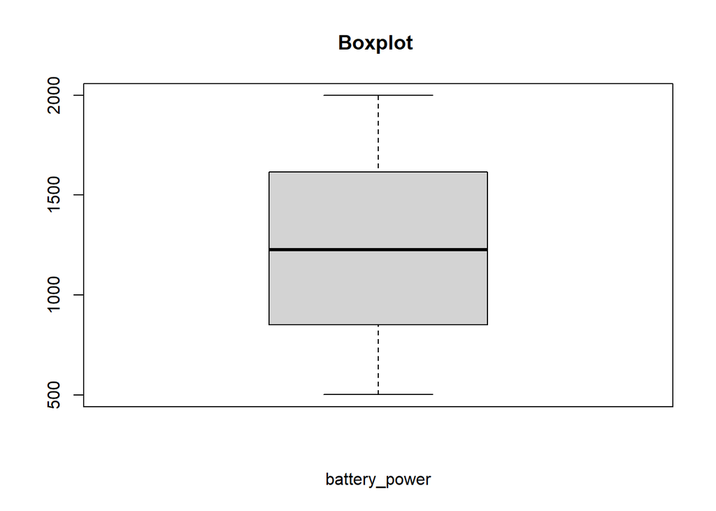

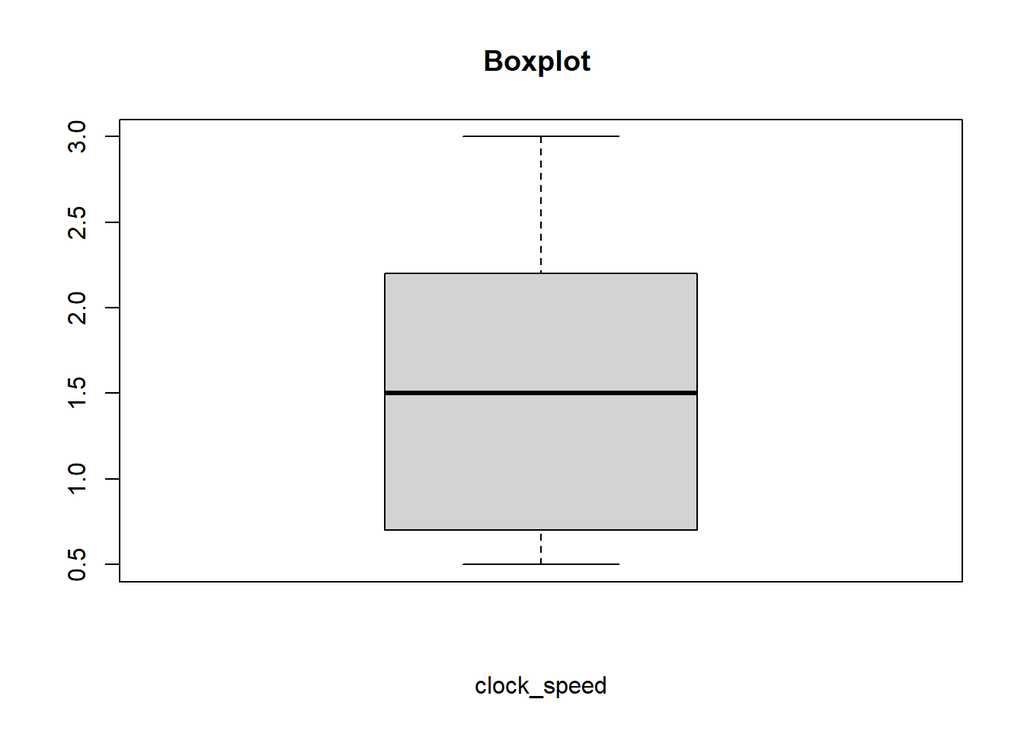

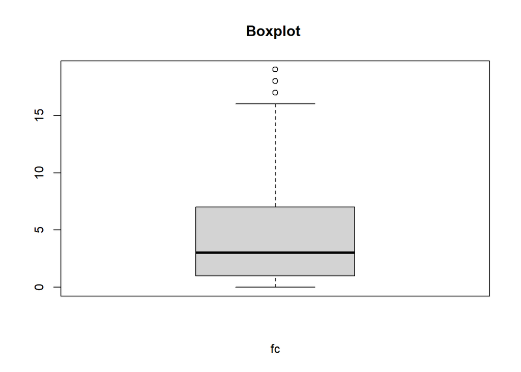

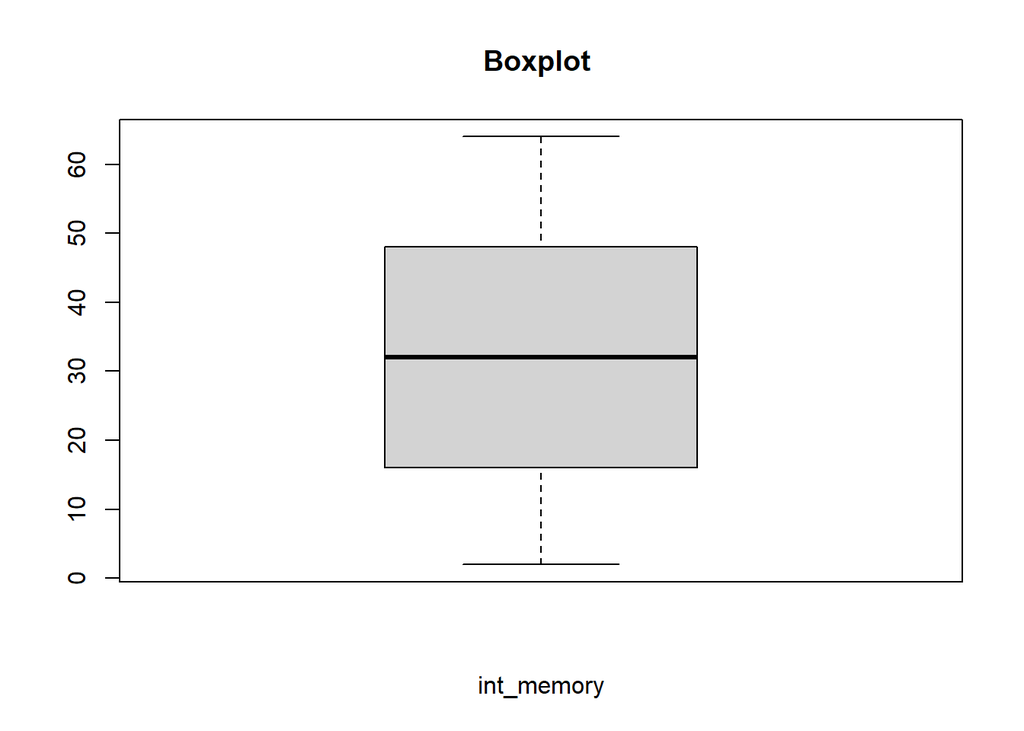

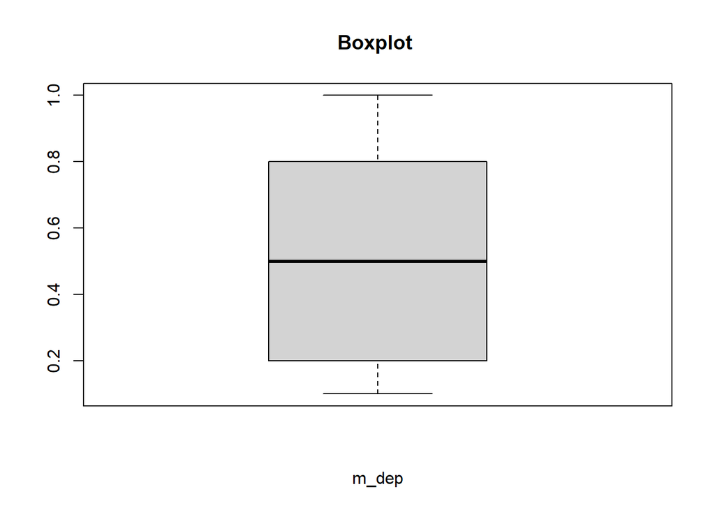

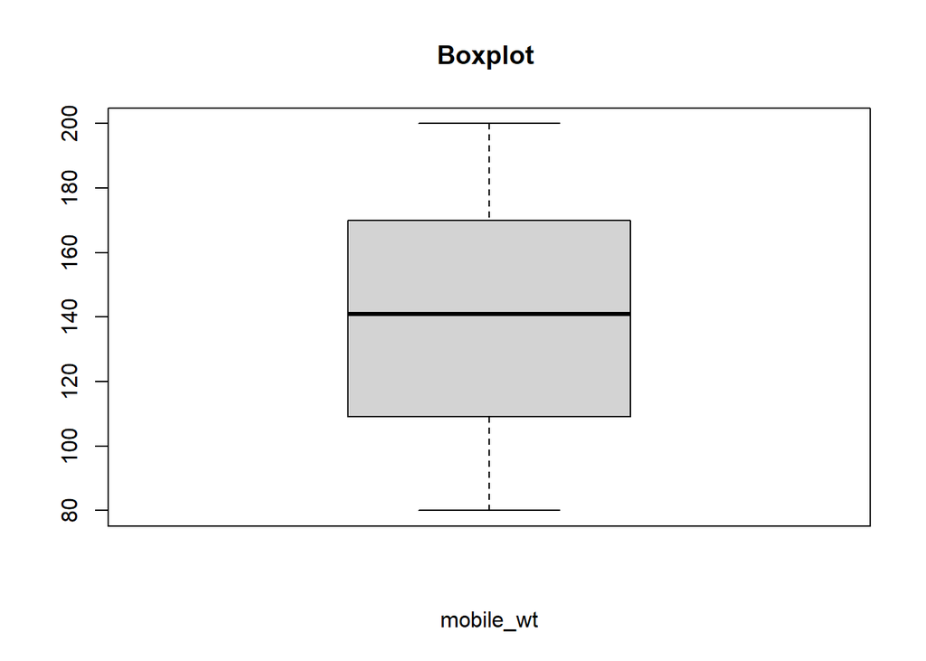

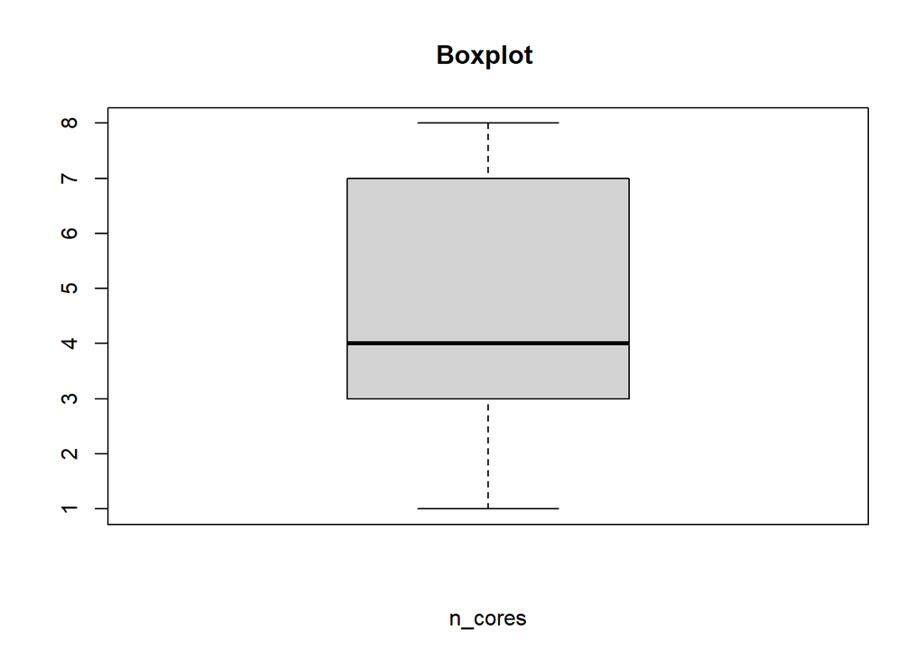

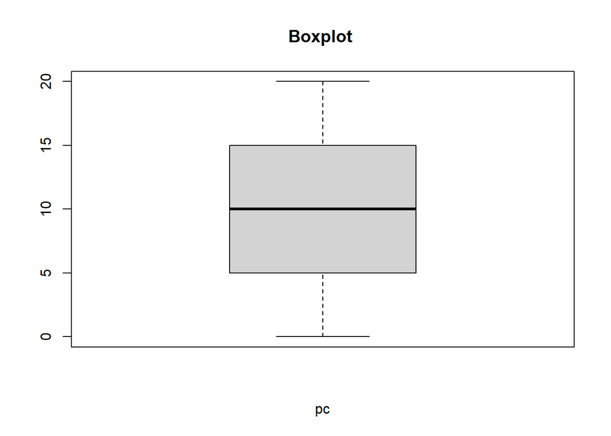

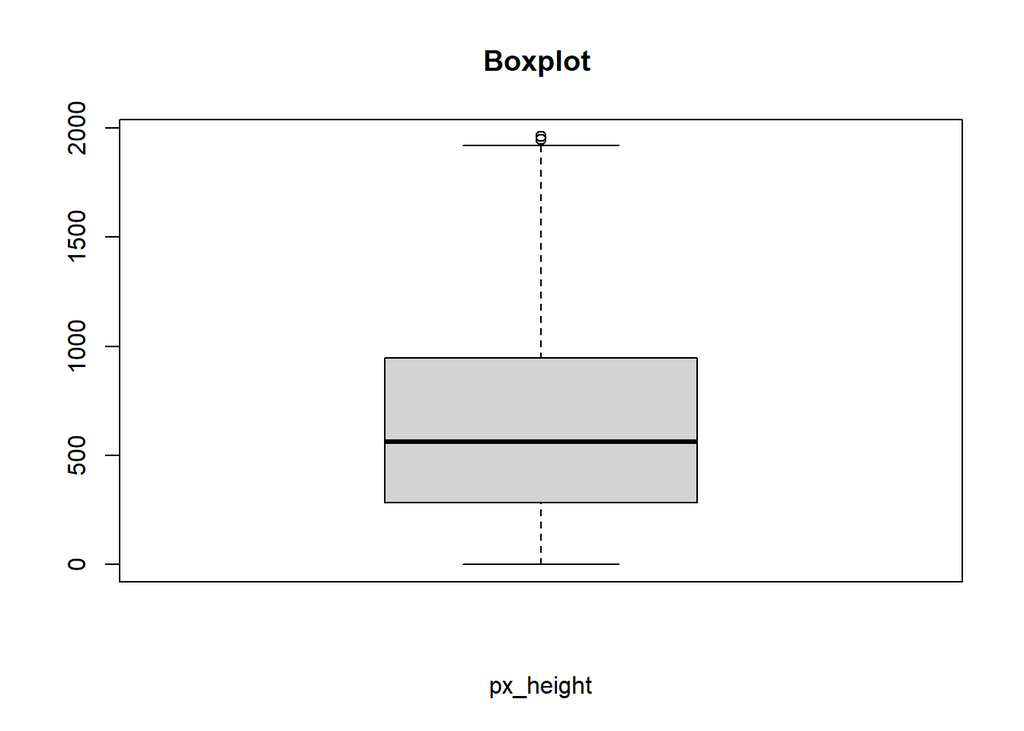

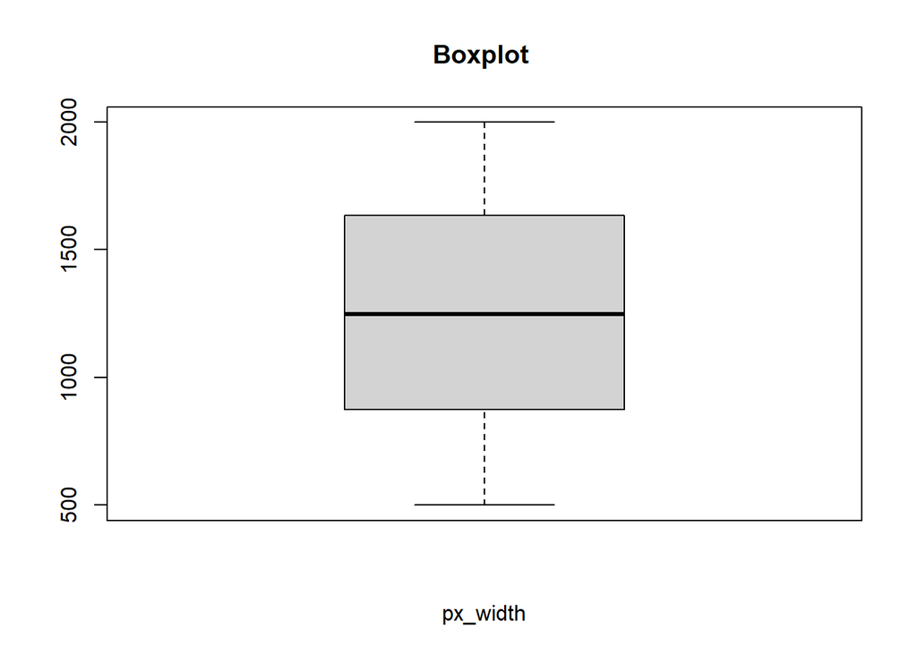

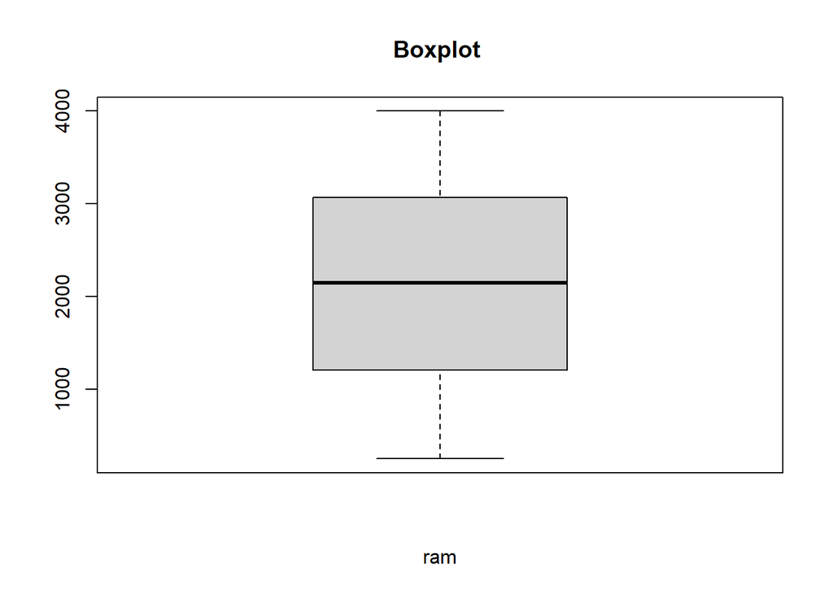

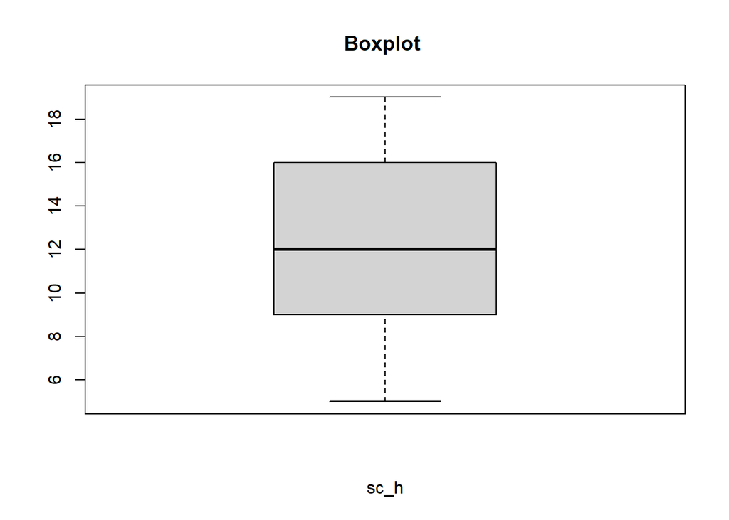

[2 more figures not shown]

[output not shown]

[output cut: 321 more lines]

[output not shown]

```r
# Plotting boxplots to check for outliers
op <- par(mfrow=c(1,1))  # to put boxplots side by side
lapply(seq(num_df), function(x)
  boxplot(x=num_df[[x]], xlab=names(num_df)[x], main=paste("Boxplot",colnames(num_df[,x]))))
```

```r
par(op)
```

### Anomaly Detection

```r
summary(num_df)
```

```
##  battery_power     clock_speed          fc           int_memory
##  Min.   : 501.0   Min.   :0.500   Min.   : 0.000   Min.   : 2.00
##  1st Qu.: 851.8   1st Qu.:0.700   1st Qu.: 1.000   1st Qu.:16.00
##  Median :1226.0   Median :1.500   Median : 3.000   Median :32.00
##  Mean   :1238.5   Mean   :1.522   Mean   : 4.309   Mean   :32.05
##  3rd Qu.:1615.2   3rd Qu.:2.200   3rd Qu.: 7.000   3rd Qu.:48.00
##  Max.   :1998.0   Max.   :3.000   Max.   :19.000   Max.   :64.00
##      m_dep          mobile_wt        n_cores            pc
##  Min.   :0.1000   Min.   : 80.0   Min.   :1.000   Min.   : 0.000
##  1st Qu.:0.2000   1st Qu.:109.0   1st Qu.:3.000   1st Qu.: 5.000
##  Median :0.5000   Median :141.0   Median :4.000   Median :10.000
##  Mean   :0.5018   Mean   :140.2   Mean   :4.521   Mean   : 9.916
##  3rd Qu.:0.8000   3rd Qu.:170.0   3rd Qu.:7.000   3rd Qu.:15.000
##  Max.   :1.0000   Max.   :200.0   Max.   :8.000   Max.   :20.000
##    px_height         px_width           ram            sc_h
##  Min.   :   0.0   Min.   : 500.0   Min.   : 256   Min.   : 5.00
##  1st Qu.: 282.8   1st Qu.: 874.8   1st Qu.:1208   1st Qu.: 9.00
##  Median : 564.0   Median :1247.0   Median :2146   Median :12.00
##  Mean   : 645.1   Mean   :1251.5   Mean   :2124   Mean   :12.31
##  3rd Qu.: 947.2   3rd Qu.:1633.0   3rd Qu.:3064   3rd Qu.:16.00
##  Max.   :1960.0   Max.   :1998.0   Max.   :3998   Max.   :19.00
##       sc_w          talk_time
##  Min.   : 0.000   Min.   : 2.00
##  1st Qu.: 2.000   1st Qu.: 6.00
##  Median : 5.000   Median :11.00
##  Mean   : 5.767   Mean   :11.01
##  3rd Qu.: 9.000   3rd Qu.:16.00
##  Max.   :18.000   Max.   :20.00
```

From the summary we note that there are no anomalies that can be detected at this point.

## EXPLORATORY DATA ANALYSIS

### UNIVARIATE ANALYSIS

```r
#Converting the encoded columns back to names
phone_df$price_range <- factor(phone_df$price_range, levels = c(0,1,2,3),
                       labels = c("low cost", "medium cost", "high cost", "very high cost"))

phone_df$blue <- factor(phone_df$blue, levels = c(0,1),
                                  labels = c("not", "yes"))
phone_df$dual_sim <- factor(phone_df$dual_sim, levels = c(0,1),
                               labels = c("not", "yes"))
phone_df$four_g <- factor(phone_df$four_g, levels = c(0,1),
                               labels = c("not", "yes"))
phone_df$three_g <- factor(phone_df$three_g, levels = c(0,1),
                               labels = c("not", "yes"))
phone_df$touch_screen <- factor(phone_df$touch_screen, levels = c(0,1),
                               labels = c("not", "yes"))
phone_df$wifi <- factor(phone_df$wifi, levels = c(0,1),
                               labels = c("not", "yes"))
```

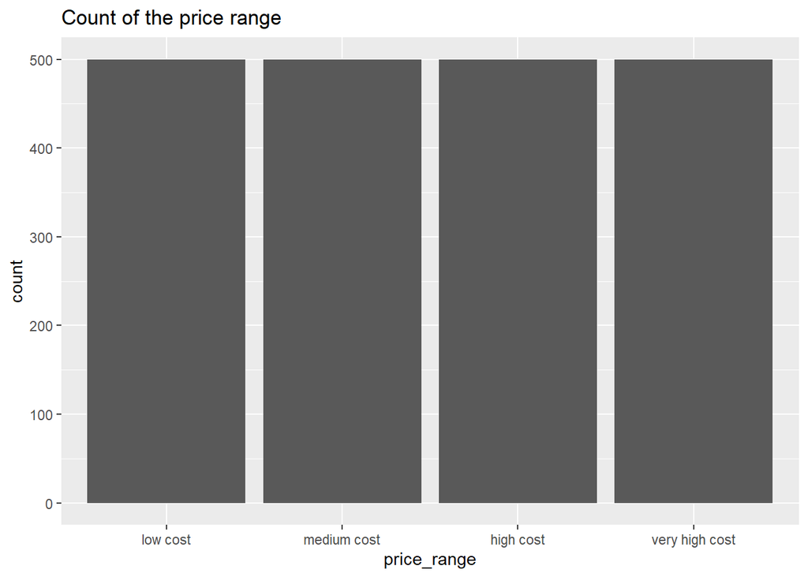

```r
#plotting price range
library(ggplot2)
ggplot(data=phone_df, aes(x = price_range)) +
  geom_bar() + labs(title = "Count of the price range")
```

Dataset has the same amount in each class that consist of low cost, medium cost, high cost, and very high cost.

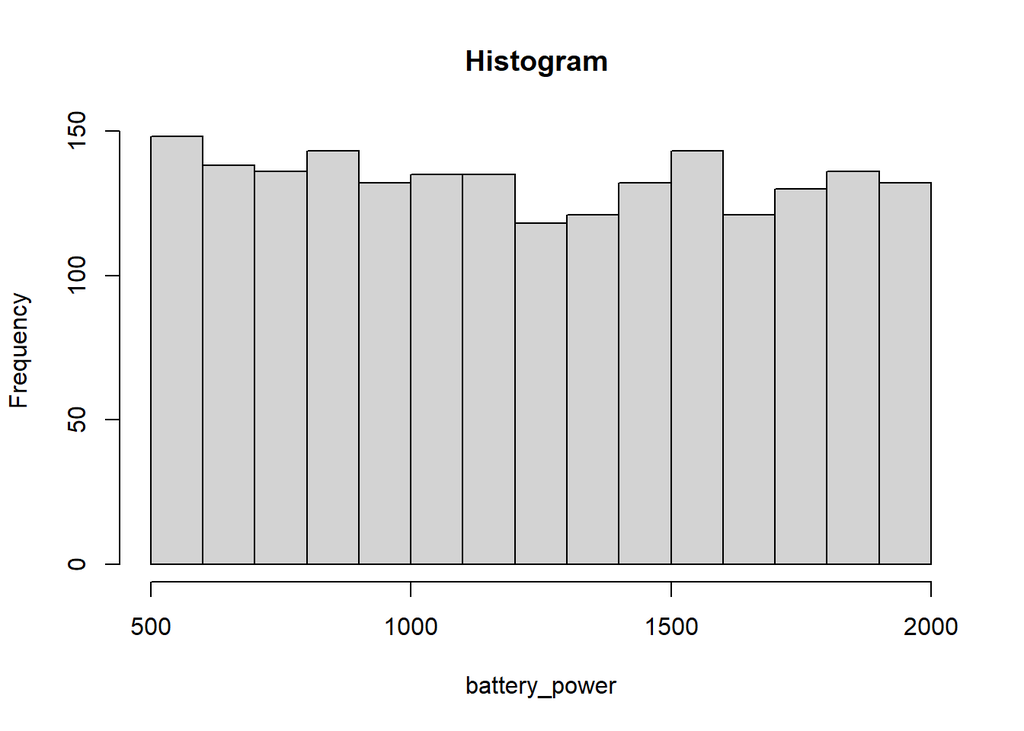

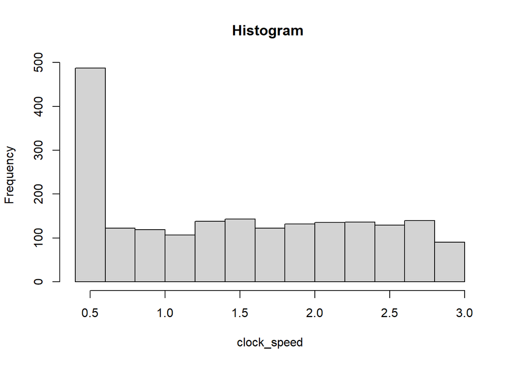

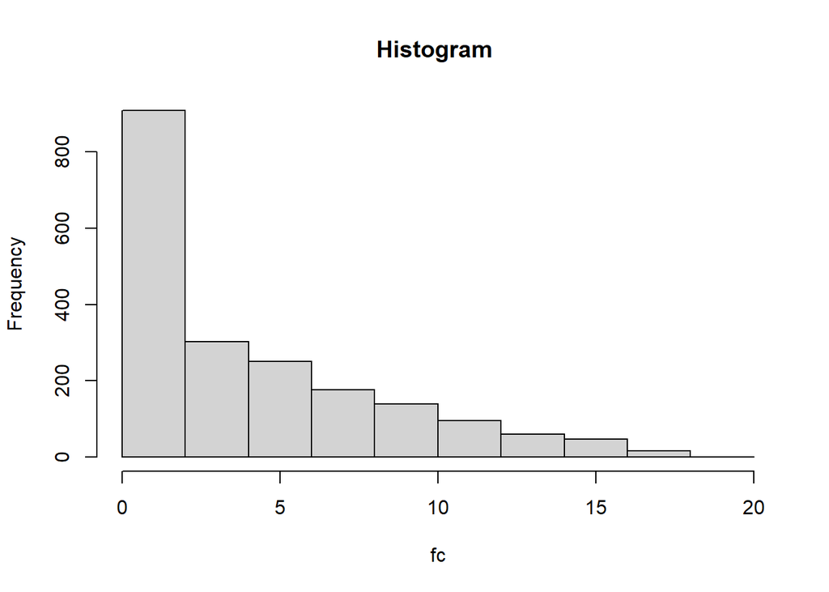

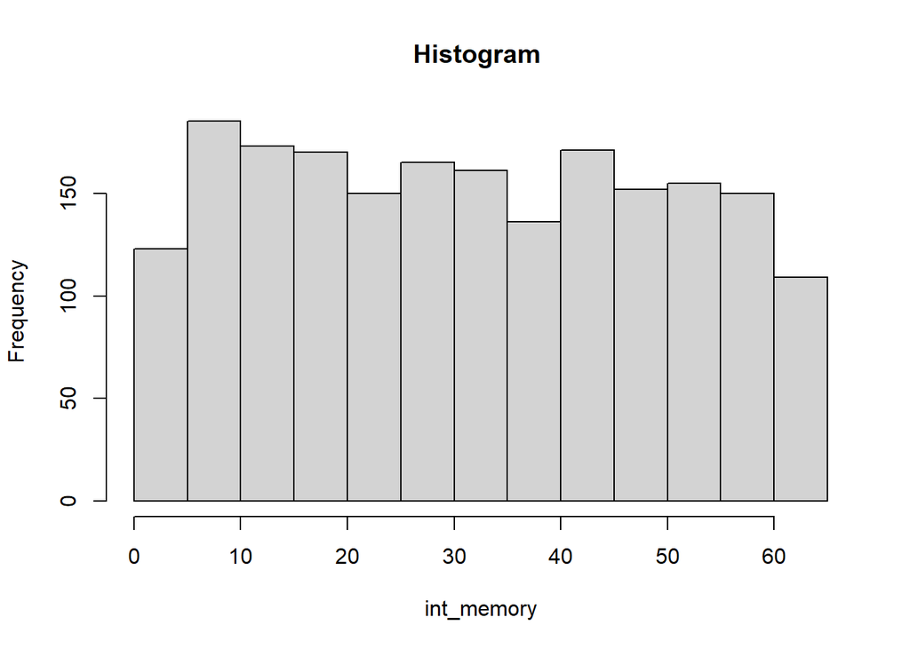

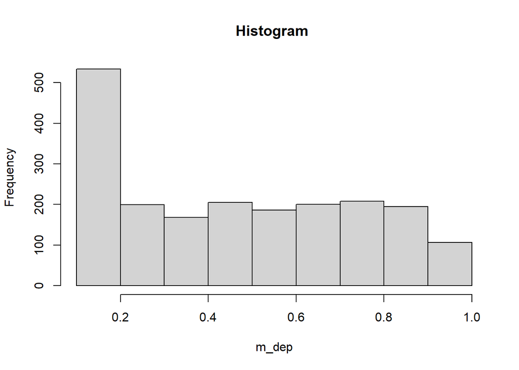

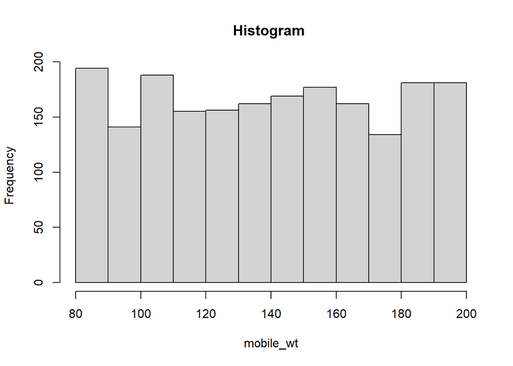

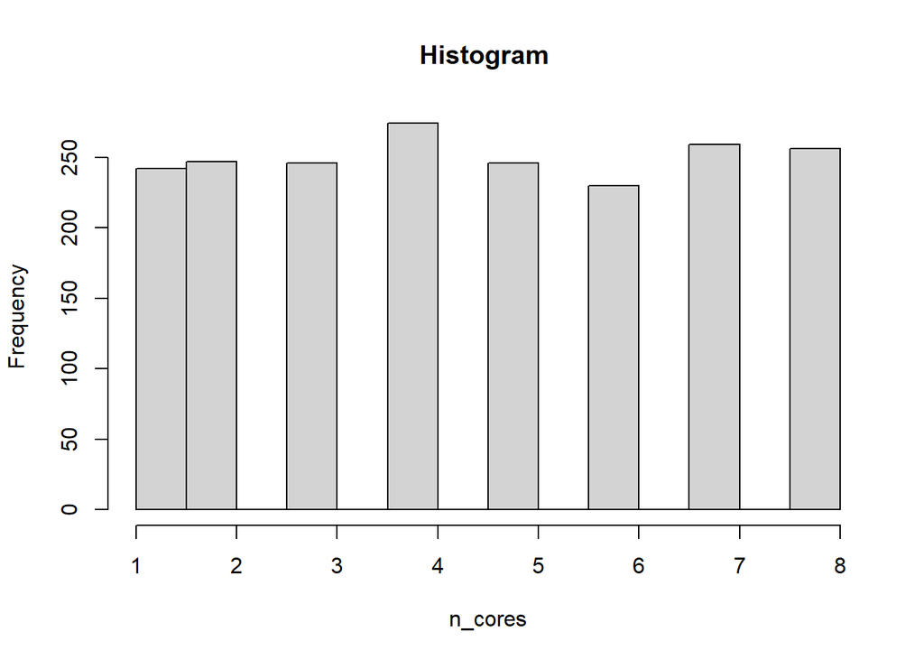

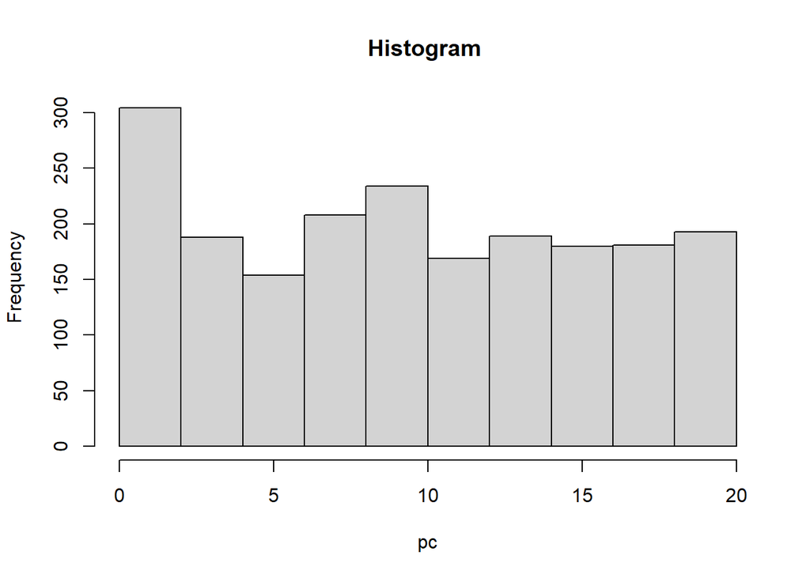

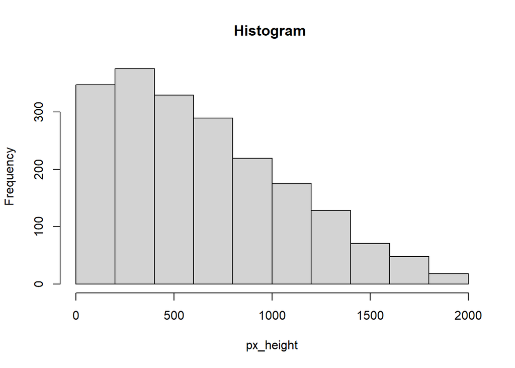

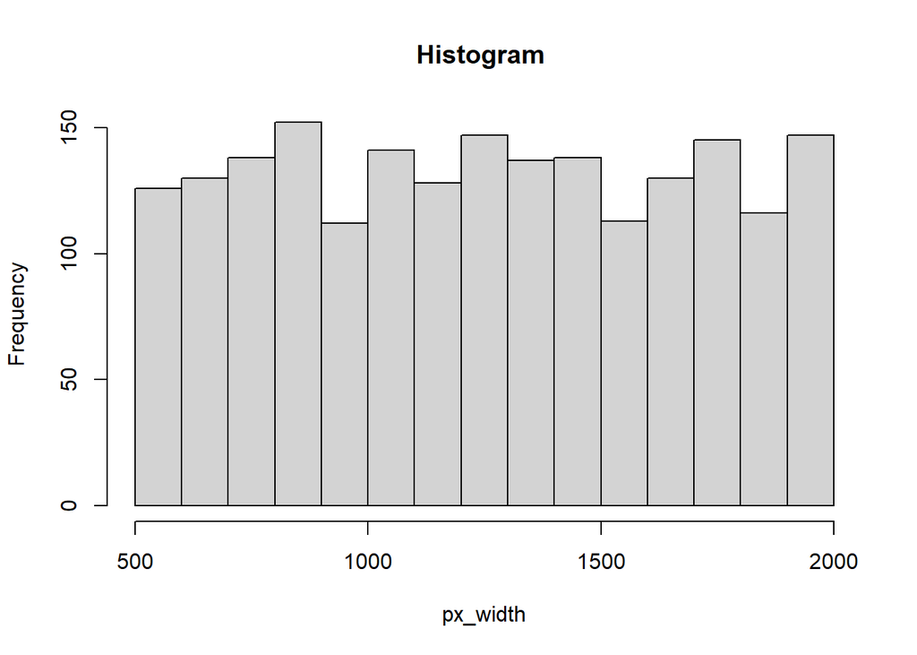

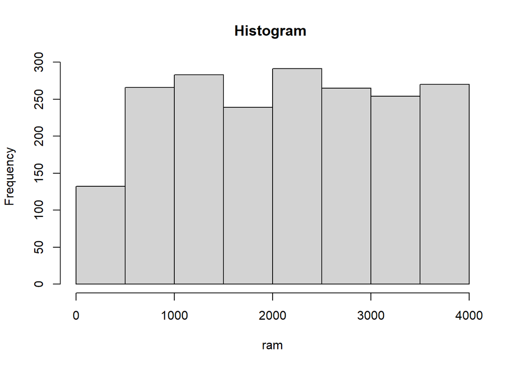

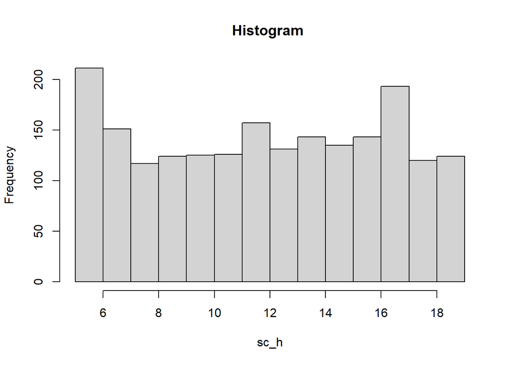

[2 more figures not shown]

[output not shown]

[output cut: 264 more lines]

[output not shown]

```r
op <- par(mfrow=c(1,1))  # to put histograms side by side
lapply(seq(num_df), function(x)
  hist(x=num_df[[x]], xlab=names(num_df)[x], main=paste("Histogram",colnames(num_df[,x]))))
```

```r
par(op)
```

### BIVARIATE DATA ANALYSIS

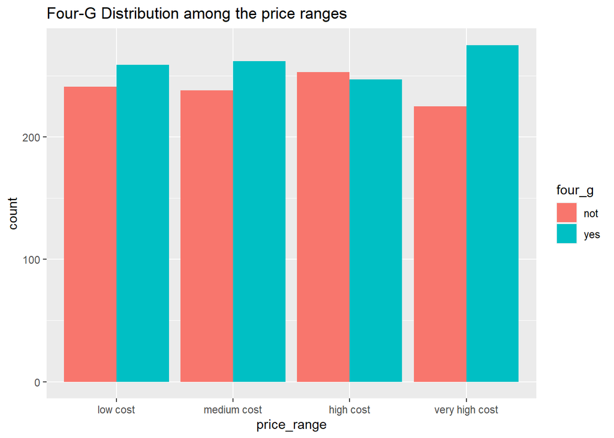

```r
#Plotting four_G and price range

ggplot(phone_df, aes(x=price_range, fill = four_g)) +
  geom_bar(position = "dodge") + labs(title = "Four-G Distribution among the price ranges")
```

From the phones on the dataset, we note that there is a difference in the four_g phones with a very high cost. Most phones on that range are 4_gs.

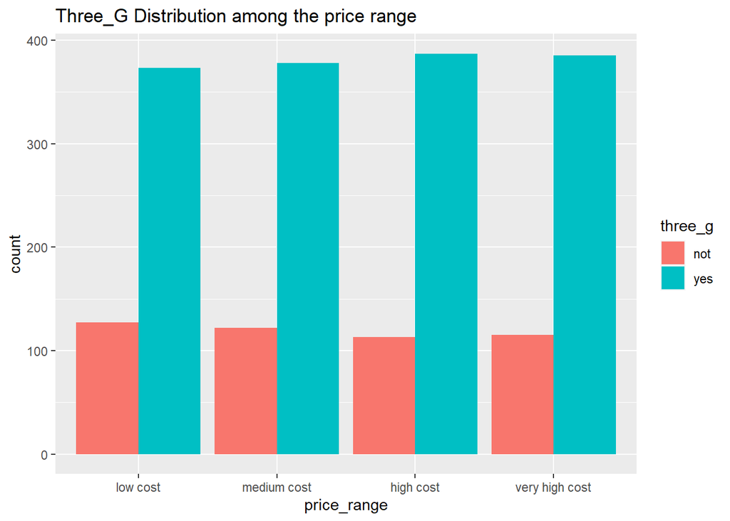

```r
#Plotting three_G and price range

ggplot(phone_df, aes(x=price_range, fill = three_g)) +
  geom_bar(position = "dodge") + labs(title = "Three_G Distribution among the price range")
```

There is a very low amount of phones that are not 3_G enabled accross all price ranges.

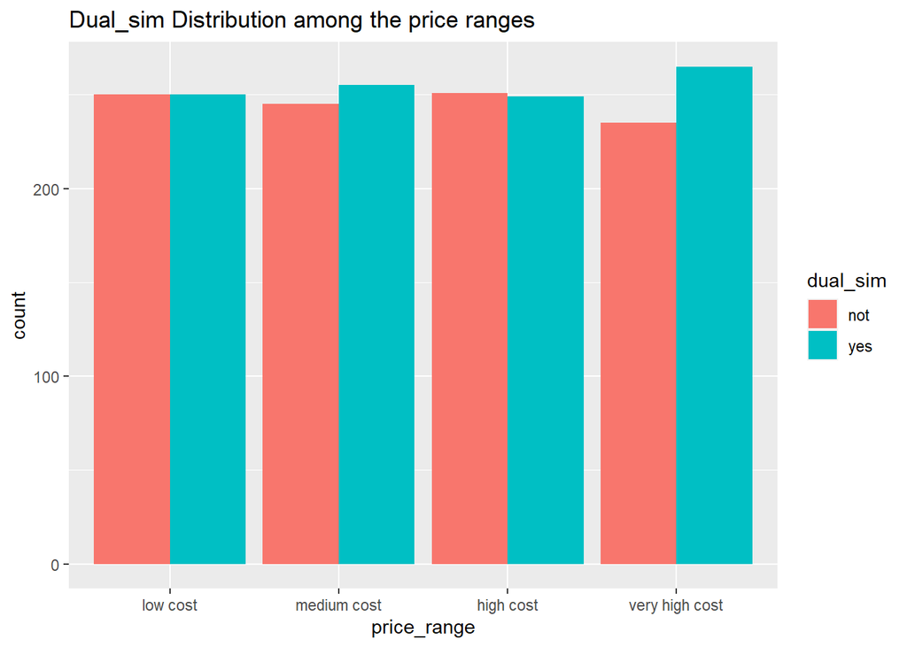

```r
#Plotting dual sim and price range
library(ggplot2)

ggplot(phone_df, aes(x=price_range, fill = dual_sim)) +
  geom_bar(position = "dodge") + labs(title = "Dual_sim Distribution among the price ranges")
```

- low cost mobile are bought equally with without dual sim.
- Medium cost mobiles with dual sim are bought more than without.
- High cost mobile are bought equally with without dual sim.
- Very high cost mobile with dula sim are bought more that those without.

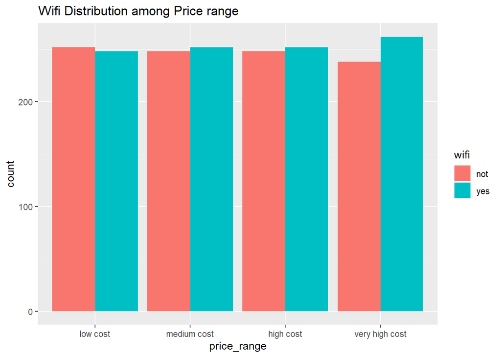

```r
#Ploting mobiles with wifi aganist price range
ggplot(phone_df, aes(x=price_range, fill = wifi)) +
  geom_bar(position = "dodge") + labs(title = "Wifi Distribution among Price range")
```

* low cost mobile with wifi have a small diffence on how they are bought. * Medium cost mobiles with wifi have a small diffence on how they are bought. * High cost mobile with wifi have a small diffence on how they are bought. * Very high cost mobile with with wife are bought more that those without.

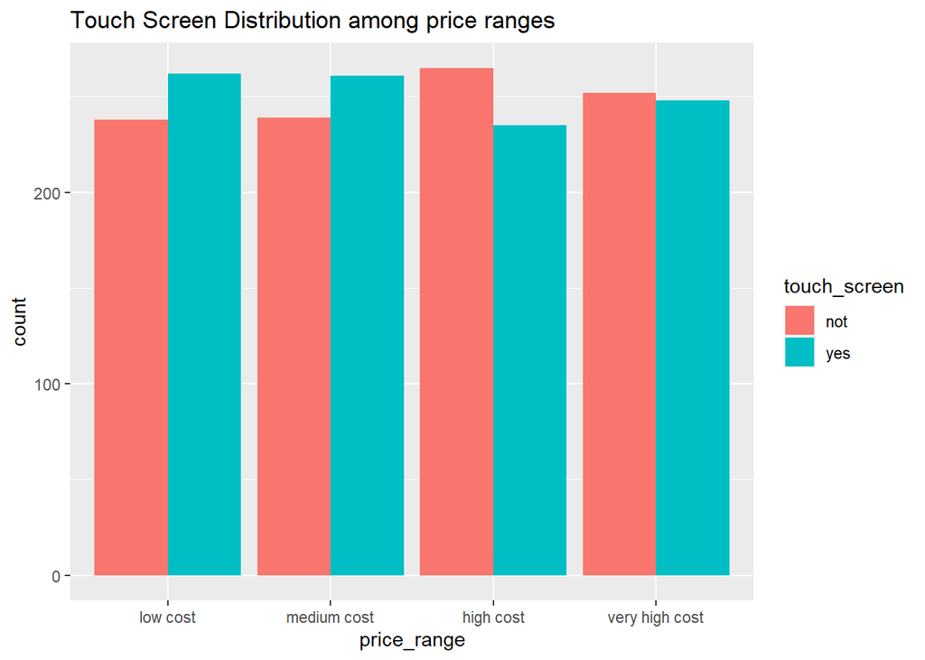

```r
#Ploting mobiles that are touch screen aganist price range
ggplot(phone_df, aes(x=price_range, fill = touch_screen)) +
  geom_bar(position = "dodge") + labs(title = "Touch Screen Distribution among price ranges")
```

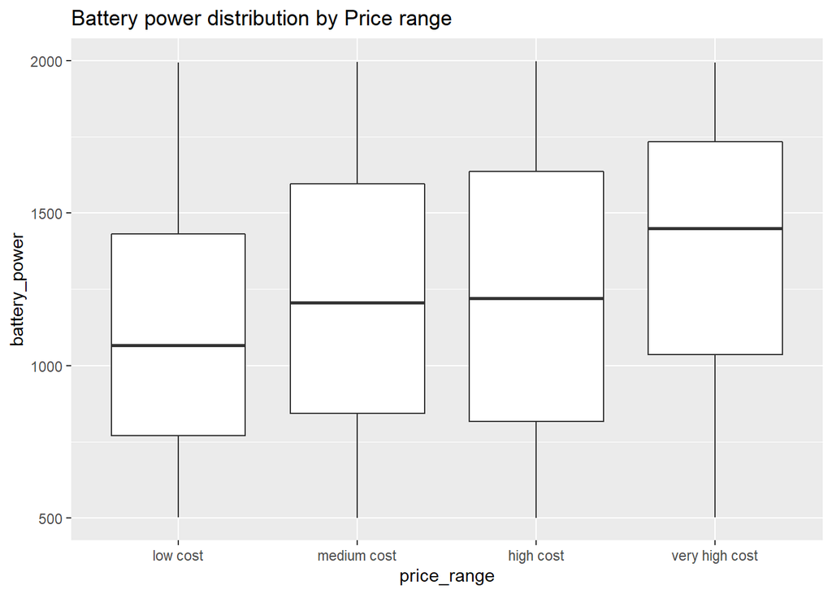

```r
ggplot(phone_df, aes(x=price_range, y=battery_power))+ geom_boxplot() + labs(title = "Battery power distribution by Price range")
```

From the boxplots above we note that as the battery capacity increases the price range of the phone increases.

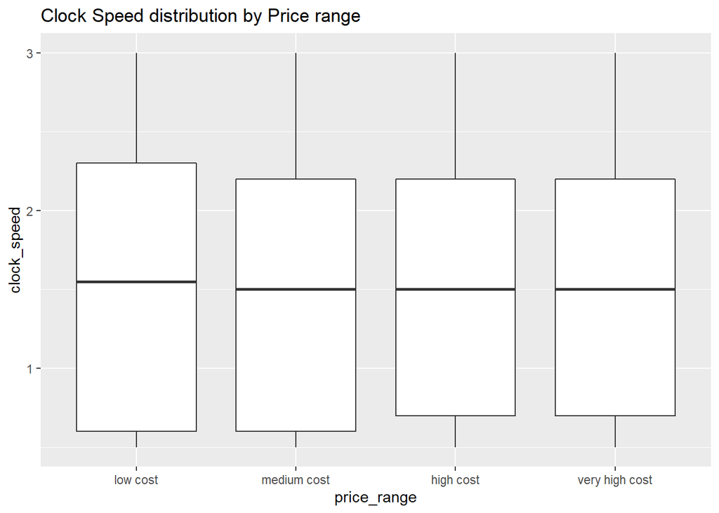

```r
ggplot(phone_df, aes(x=price_range, y=clock_speed))+ geom_boxplot() + labs(title = "Clock Speed distribution by Price range")
```

We also note that the clock speed does not affect the price of the phones.